# Eusipco Demo

```python
import numpy as np
import matplotlib.pyplot as plt
import argparse
import seaborn as sns
import os
import json
from pathlib import Path

plt.style.use('seaborn-darkgrid')
sns.set_context("talk")
def plot_loss_curves(p):
    fig1, ax = plt.subplots(1, 1, figsize=(15,8))
    p = Path(p)
    with open(p, 'r') as stream:
        r = json.load(stream)

    ax.plot(
        r['train_loss_history'],
        label='train',
        linewidth='2',
    )

    ax.plot(
        r['valid_loss_history'],
        label='validation',
        linewidth='2',
    )
    ax.set_yscale('log')
    ax.set_title(p.stem)
    plt.xlabel('Epoch')
    plt.ylabel('MSE Loss')
    plt.legend()
```

# Original ISMIR Model

- instance norm of the mixture prevented to learn the scale

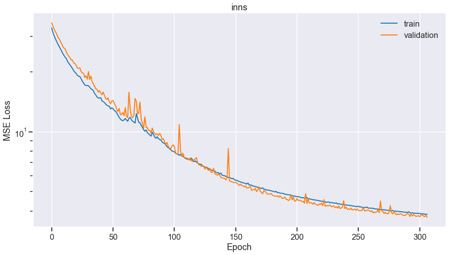

```python
plot_loss_curves("/Users/faro/Dropbox/eusipco_tutorial/inns.json")
```

# Now, we want the model to predict the real magnitude

lets change the output of the model to predict

```
return x * mix
```

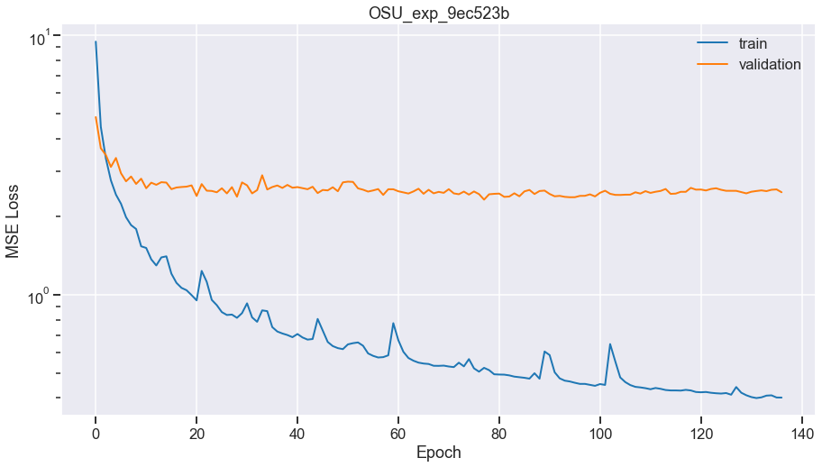

```python
plot_loss_curves("/Users/faro/Dropbox/eusipco_tutorial/OSU_exp_9ec523b.json")
```

Now what, happens is that the model crazily overfits since the problem becomes too easy (we could see that in the performance gap between `train` and `test`).

**we lost more than 2dB compared to the old model!**

# But the model should be good, no?

- we believe in our model so it should be the training that would need to be improved
- we made the sampling strategy stochstic, so that each epoch does get the same but random excerpts
- give more patience for early stopping
- introduce fixed learning rate decay (120 epochs)

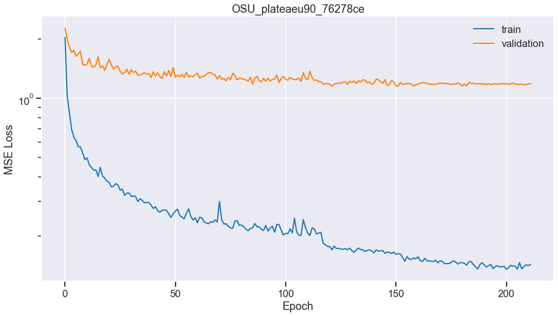

```python
plot_loss_curves("/Users/faro/Dropbox/eusipco_tutorial/OSU_plateaeu90_76278ce.json")
```

- this gets us back to 5.6 dB SDR (vocals) (as good as INNS)
- however, gap between train and test is quite large
- more training tricks would need to be applied

# The final training tricks

- add data augmentations **per source** and dynamically mix the sources together
- take sources from random tracks
- add l2 regularization
- increase dropout to 0.4
- schedule learning rate decay dynamically on plateeua (*0.1)

### ...and run a lot of seeds and select the best model by best validation loss

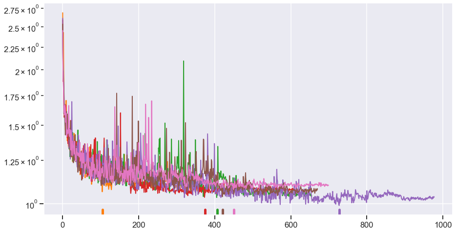

```python
fig1, ax = plt.subplots(1, 1, figsize=(15,8))
prop_cycle = plt.rcParams['axes.prop_cycle']
colors = prop_cycle.by_key()['color']
p = Path("/Users/faro/Dropbox/eusipco_tutorial/UMX-Final/")
for i, x in enumerate(p.iterdir()):
    if x.suffix == '.json':
        with open(x, 'r') as stream:
            r = json.load(stream)

        ax.plot(
            r['valid_loss_history'],
            label='validation',
            linewidth='2',
            c=colors[i]
        )
        ax.axvline(int(r['best_epoch']), ymax=.025, ymin=0, c=colors[i], lw=5)
        ax.set_yscale('log')
```

# Final model

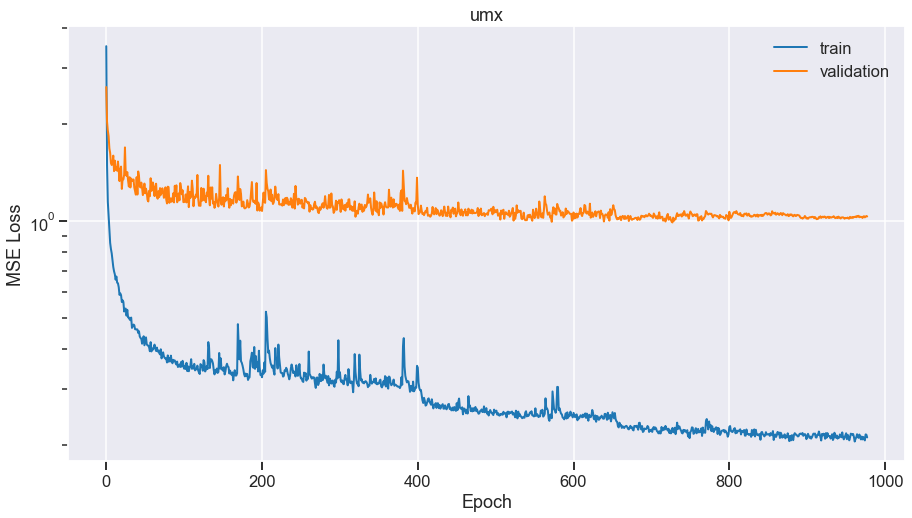

```python
plot_loss_curves("/Users/faro/Dropbox/eusipco_tutorial/umx.json")
```